# Lab 5

Mario Perales

February 22 2016

*Source file* ⇒ lab5.Rmd  
We first begin by loading the data we are loading with:

```r
set.seed(123)
d <- diamonds[sample(nrow(diamonds), 1000), ]
head(d)
```

```
## Source: local data frame [6 x 10]
##
##   carat       cut  color clarity depth table price     x     y     z
##   (dbl)    (fctr) (fctr)  (fctr) (dbl) (dbl) (int) (dbl) (dbl) (dbl)
## 1  1.03   Premium      G     VS2  62.3    59  6214  6.38  6.42  3.99
## 2  0.50      Fair      D     SI1  65.7    56  1323  5.01  4.97  3.28
## 3  1.74 Very Good      H     SI2  62.1    59 10086  7.65  7.78  4.79
## 4  0.51     Ideal      D     VS2  61.2    55  1882  5.18  5.16  3.16
## 5  0.70     Ideal      H     SI1  62.5    56  2294  5.64  5.69  3.54
## 6  0.71     Ideal      H      IF  62.0    54  3190  5.71  5.75  3.55
```

We then see that it is broken into **facets** arranged by **cut**. We now notice that there are loess smoothed curved in each facet, with each **fill** and **line** being distinguished by **color** associated with the variable **cut**.

Now, we give a **title**, **x-axis title**, and **y-axis title** to our graph. In the *theme* function, we begin to modify the title’s text **sizes** as well as their **color** to match the given graph. We also take into account that the **x-axis ticks** are *blank* while the **y-axis ticks** are written in a **red** color with a corresponding **size**.

Finally, we adjust the plot’s width and height display on *R Markdown* via the *fig.width* and *fig.height* functions.

In the end, we produce the following graph:

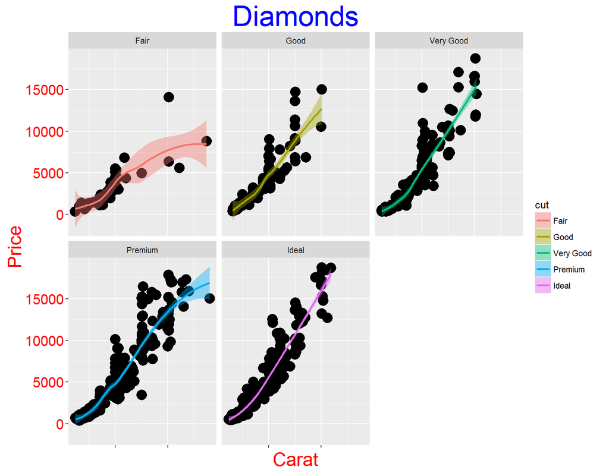

```r
ggplot(data = d, aes(x = carat, y = price)) +
    geom_point(size = 5) +
    geom_smooth(aes(color = cut, fill = cut)) +
    facet_wrap(~cut) +
    labs(title = "Diamonds",x = "Carat", y = "Price") +
    theme(
        plot.title = element_text(size = 30, color = "blue"),
        axis.title.x = element_text(size = 20, color = "red"),
        axis.title.y = element_text(size = 20, color = "red"),
        axis.text.x = element_blank(),
        axis.text.y = element_text(size = 15, color = "red")
    )
```